# Benchmarking feature selection methods with different prediction models on large-scale healthcare event data - ScienceDirect

## [BenchCouncil Transactions on Benchmarks, Standards and Evaluations](https://www.sciencedirect.com/journal/benchcouncil-transactions-on-benchmarks-standards-and-evaluations)

[Volume 1, Issue 1](https://www.sciencedirect.com/journal/benchcouncil-transactions-on-benchmarks-standards-and-evaluations/vol/1/issue/1), October 2021, 100004

# Benchmarking feature selection methods with different prediction models on large-scale healthcare event data

https://doi.org/10.1016/j.tbench.2021.100004[Get rights and content](https://s100.copyright.com/AppDispatchServlet?publisherName=ELS&contentID=S2772485921000041&orderBeanReset=true)

Under a Creative Commons [license](http://creativecommons.org/licenses/by-nc-nd/4.0/)

open access

Referred to by

[View PDF](https://www.sciencedirect.com/science/article/pii/S2772485923000182/pdfft?md5=c0e66bbba9ba426bb2eb4575ebe7dd2e&pid=1-s2.0-S2772485923000182-main.pdf)

## Abstract

With the development of the Electronic Health Record (EHR) technique, vast volumes of digital clinical data are generated. Based on the data, many methods are developed to improve the performance of clinical predictions. Among those methods, [Deep Neural Networks](https://www.sciencedirect.com/topics/computer-science/deep-neural-network) (DNN) have been proven outstanding with respect to accuracy by employing many patient instances and events (features). However, each patient-specific event requires time and money. Collecting too many features before making a decision is insufferable, especially for time-critical tasks such as mortality prediction. So it is essential to predict with high accuracy using as minimal clinical events as possible, which makes feature selection a critical question. This paper presents detailed benchmarking results of various feature selection methods, applying different classification and regression algorithms for clinical prediction tasks, including mortality prediction, length of stay prediction, and ICD-9 code group prediction. We use the publicly available dataset, Medical [Information Mart](https://www.sciencedirect.com/topics/computer-science/information-mart) for Intensive Care III (MIMIC-III), in our experiments. Our results show that Genetic Algorithm (GA) based methods perform well with only a few features and outperform others. Besides, for the mortality prediction task, the feature subset selected by GA for one classifier can also be used to others while achieving good performance.

## Keywords

Feature selection

Genetic algorithm

Deep neural networks

Healthcare prediction

## 1. Introduction

Over the past decades, the Electronic Health Record (EHR) technique is developed; vast volumes of digital clinical data are generated, making it possible for [Clinical Decision Support Systems](https://www.sciencedirect.com/topics/computer-science/clinical-decision-support-system) (CDSSs) to make better decisions. For example, public databases such as MIMIC-III [1] have promoted the research in clinical predictions. Based on those databases, different severity scoring systems, traditional [machine learning](https://www.sciencedirect.com/topics/computer-science/machine-learning) algorithms, and [DNNs](https://www.sciencedirect.com/topics/computer-science/deep-neural-network) are developed and continuously improved to achieve better clinical prediction tasks such as patient mortality, disease classification, and length of hospital stay.

Traditional severity scores like Simplified Acute Physiology Score (SAPS-II) [2], the Sepsis-related Organ Failure Assessment (SOFA) [3], and Acute Physiology and Chronic Health Evaluation (APACHE) [4] are standard for mortality prediction in practice. Clinicians usually choose the patient-specific events they used based on their experience. Then a standard process is implemented. First, a severity score is calculated based on the relative events, usually measured within the first 24 h after ICU admission. Second, a simple model such as [logistic regression](https://www.sciencedirect.com/topics/computer-science/logistic-regression) is applied to the score to predict the final death probability.

Recent work shows that DNN and Super Learner (SL) algorithms perform better than single traditional classifiers and severity scoring systems [5], [6], [7], [8]. To improve the [predictive performance](https://www.sciencedirect.com/topics/computer-science/predictive-performance), many DNN models are developed. Purushotham et al. [6] proposed a Multimodal [Deep Learning Model](https://www.sciencedirect.com/topics/computer-science/deep-learning-model) (MMDL) to process an extensive feature set, which consists of 141 features, and got very good predicting results. Harutyunyan et al. [7] proposed a multitask LSTM-based method to predict four clinical prediction tasks. In addition to DNN, SL is also studied extensively and shows promising results. Pirracchio et al. [5] provided and assessed the performance of the Super ICU Learner Algorithm (SICULA). Lee et al. [8] trained case-specific [Random Forests](https://www.sciencedirect.com/topics/computer-science/random-decision-forest) (RF) to make mortality prediction and exhibited the best AUROC compared with other single models such as death counting, logistic regression, and [decision tree](https://www.sciencedirect.com/topics/computer-science/decision-trees).

No matter which method we use, feature selection is an important part. First, medical databases store vast amounts of clinical events and not all of them are related to the target task. Second, minimal clinical events enable doctors to make timely decisions. For severity scoring systems, a set of alternated related events is chosen based on clinicians’ experience. A simple subset of those events is selected according to correlation coefficient or other index associated with the target concept of the prediction task [2], [3], [4], [9]. Traditional machine learning and [deep learning algorithms](https://www.sciencedirect.com/topics/computer-science/deep-learning) usually take the same features directly used in severity scores [6], [7] or take a similar method to select features [10]. In this paper, we do an exhaustive evaluation of various feature selection methods, and our main contributions are listed below.

- (1)

  Benchmarking feature selection methods including traditional severity scores, machine learning-based feature selection methods, and evolutionary computing GA for three clinical prediction tasks.
- (2)

  Compare feature subsets selected by GA for different classifiers. The results show that for the mortality prediction task, the features chosen by GA are universal for different classifiers.

The rest of this paper is organized as follows: in Section 2, we provide an overview of the related work; in Section 3, we describe the dataset and methods we employed; in Section 4, the benchmarking experiments and results are reported and discussed in detail; in Section 5, we summarize the paper.

## 2. Related work

First, we summarize the feature selection algorithms that are applied in the medical field. Then we discuss the existing benchmarks on healthcare datasets, especially for MIMIC-III. The comparison of benchmarks is listed in Table 1.

The first severity scores proposed such as APACHE [4], APACHE-II [11], and SAPS [12] selected features based on experience of medical experts. Further work usually used statistical methods to calculate correlation coefficient associated with target prediction task, such as [2], [13], [14]. Since publication, all of the methods have been continuously modified to improve the [predictive performance](https://www.sciencedirect.com/topics/computer-science/predictive-performance) [15]. A lot of work employed GA to select risk factors and predict in-hospital mortality [9], [10], [16], [17], [18], [19]. In this work, we report an exhaustive set of benchmarking results of feature selection methods, including GA.

Table 1. Comparison of benchmarking works.

| Empty Cell | Empty Cell | [7] | [6] | [10] | This work |
| --- | --- | --- | --- | --- | --- |
| Number of features | Smaller feature set | ✓ | ✓ | ✓ | ✓ |
|  | Larger feature set |  | ✓ | ✓ | ✓ |
| Feature type | Non-time series |  | ✓ | ✓ | ✓ |
|  | Time-series | ✓ | ✓ | ✓ | ✓ |
| Feature selection methods | Severity score | ✓ | ✓ | ✓ | ✓ |
|  | Machine learning |  |  | ✓ | ✓ |
|  | Evolutionary computing GA |  |  | ✓ | ✓ |
| Classifications methods | Traditional machine learning | ✓ | ✓ | ✓ | ✓ |
|  | DNN | ✓ | ✓ |  | ✓ |
| Prediction tasks | Mortality | ✓ | ✓ | ✓ | ✓ |
|  | Length of stay | ✓ | ✓ |  | ✓ |
|  | Phenotyping | ✓ |  |  |  |
|  | ICD-9 code group | ✓ | ✓ |  | ✓ |

Public datasets such as MIMIC-III have promoted the benchmarking of models for clinical prediction tasks. Purushotham et al. [6] benchmarked [deep learning models](https://www.sciencedirect.com/topics/computer-science/deep-learning-model) based on an extensive feature set and get high Area Under the Receiver Operating Characteristic Curve (AUROC) and Area under Precision–Recall Curve (AUPRC). The complete feature set we used is the same as the feature set C in [6], which contains 136 time-series features and five non-time series features. Harutyunyan et al. [7] first benchmarked four clinical prediction tasks and presented a multitask classifier. The most significant difference between us and previous works is that we benchmark feature selection algorithms, especially GA, instead of classification or regression algorithms. Krishnan et al. [10] proposed a GA-based model to make mortality prediction. We extend the benchmark to the other two prediction tasks and combine GA with [DNN](https://www.sciencedirect.com/topics/computer-science/deep-neural-network) models to get higher AUROC and AUPRC. Johnson et al. [20] reproduced 28 published works for mortality prediction, and the results showed that it is a big challenge to reproduce other people’s work without public code.

## 3. Materials and methods

### 3.1. Dataset preprocessing

MIMIC-III is developed by the Massachusetts Institute of Technology (MIT)’s Laboratory for Computational Physiology and contains around 60,000 intensive care unit admissions. MIMIC-III (v1.4) consists of 46,520 distinct patients and 58,976 admissions, from where we select 35,643 admissions for our experiments. We extracted data from 5 commonly used tables, namely inputevents, outputevents, chartevents, labevents, prescriptions tables. The statistics of cohort selection are tabulated in Table 2. We selected the patient cohort based on the following criteria:

- •

  Only adult patients, whose age was >15 years at the time of ICU admission, were selected.
- •

  Only the first admission was included for each patient. This decision uses the earliest available data to predict and ensure similar data selection compared to other related works.
- •

  We only include the patients who died 24 h after the first admission.

Because the original data from MIMIC-III has erroneous records such as missing values, inconsistent units, etc., we clean data according to [6], which includes the following procedures: (a) Unify the units. (b) Select one valid record. For multiple records simultaneously, take the average values for numerical data and bring the first for [categorical data](https://www.sciencedirect.com/topics/computer-science/categorical-data). (c) Re-sample and fill-in the data. Time-series data is divided into hours and a forward–backward imputation is done to impute the missing values.

Table 2. Summary statics of cohort selection.

| Data | Total |
| --- | --- |
| Admissions in the MIMIC-III (V1.4) | 58,976 |
| The first admissions | 46,520 |
| First admissions of adult patients | 38,424 |
| Patients died 24 h after the admissions | 35,643 |

### 3.2. Prediction tasks

For benchmark, we select three clinical prediction tasks which are important in critical care research and are commonly studied by [machine learning](https://www.sciencedirect.com/topics/computer-science/machine-learning) researchers. The first is in-hospital mortality which is important for doctors to take effective actions for patient care in Intensive Care Units (ICUs) [10]. The second is ICD-9 code group prediction, where we divide the ICD-9 codes into 20 groups according to [6] and treat it as a multi-classification problem. The third is length of stay prediction, which is to predict the hospital stay after admission.

### 3.3. Feature selection/extraction methods

We extract 136 time-series features and five non-time series features as our full feature set according to [6]. Those features are selected based on clinical significance and missing rate while containing all features used in severity scoring systems such as SAPS-II and SOFA. Based on this feature set, different feature selection methods are evaluated including GA based methods, scoring methods and machine learning methods.

GA is a [metaheuristic](https://www.sciencedirect.com/topics/computer-science/metaheuristics) inspired by the process of natural selection. It can be used to generate high-quality solutions to optimization and search problems by the process of mutation, crossover, and selection [21]. It is proved to be useful in feature selection as a wrapper feature selection technique [10]. Table 3 lists the GA procedure we used.

For scoring methods, we choose two popularly used severity scores, namely SAPS-II and SOFA. SAPS-II [2] is designed to predict the probability of hospital mortality. It can be calculated based on 17 variables which can be expand into 20 raw features of our complete feature set. SOFA [3] score can be calculated based on 6 variables which can be expand into 17 raw features of our complete feature set.

Table 3. Genetic algorithm.

| Genetic Algorithm |
| --- |
| **Input:** Dataset D(X, Y) , classifier C and target number of features N |
| **Output:** Optimal N features X$′$ for C |
| 1. Randomly generate N features from X as X<sub>0</sub> |
| 2. Calculate fitness for X<sub>0</sub>, which is AUC for D(X<sub>0</sub>, Y) and C. |
| 3. Set X$′$=X<sub>0</sub> |
| 4. **while** i $≤$ 10000 **do** |
| 5. Generate a new feature set X$i$ |
| by randomly replacing one feature in X$′$ |
| 6. Calculate fitness for X$i$ |
| 7. **if** X$i$.fitness $>$ X$′$.fitness: |
| 8. X$′$=X$i$ |
| 9. **if** X$′$.fitness $⩾$ 1 |
| 10. **return** X$′$ |
| 11. **return** X$′$ |

For machine learning methods, Principal Component Analysis (PCA) [22] and Recursive Feature Elimination (RFE) are chosen.

PCA is a widely used filter feature extraction technique, which projects the data to a new orthogonal space and then chooses a few of the essential features to achieve dimensionality reduction. RFE is a wrapper feature selection technique that selects features based on the accuracy of the subsequent classifiers.

### 3.4. Classification/regression methods

For machine learning we use three common commonly used algorithms: decision tree, Bayesian ridge regression, and [logistic regression](https://www.sciencedirect.com/topics/computer-science/logistic-regression). For DNN we use three types of deep models, namely [Feedforward Neural Networks](https://www.sciencedirect.com/topics/computer-science/feedforward-neural-network) (FNN), [Recurrent Neural Networks](https://www.sciencedirect.com/topics/computer-science/recurrent-neural-network) (RNN), and Multimodal Deep Learning Model (MMDL) according to [6].

## 4. Benchmarking results

Based on the MIMIC-III dataset, we report the experimental results for three prediction tasks, which answer the following questions: (a) Can DNN models use relatively small feature subsets to perform as well as the full feature set? (b) Whether the subset of features selected by GA is universal for different classifiers of the same task?

### 4.1. Mortality prediction task evaluation

Tables 4, 5 show the results of mortality prediction task. Because PCA cannot handle time-series data, it is blank for [RNN](https://www.sciencedirect.com/topics/computer-science/recurrent-neural-network) and MMDL results. We can observe that: (a) Deep learning-based prediction models perform better than traditional machine learning-based models and obtain around 2%–20% and 10%–30% improvement for AUROC and AUPRC, respectively. (b) GA performs better and obtains around 6%–18% and 10%–40% improvement over other methods for AUROC and AUPRC, respectively. (c) Compared with using all features (141 features), GA gets similar or even better results with only 20 features.

Table 4. AUROC of in-hospital mortality prediction task.

| Algorithm Empty Cell | Algorithm Empty Cell | Score method (Features) SAPS-II (20) | Score method (Features) SOFA (17) | Feature extraction/selection (Features) PCA (20) | Feature extraction/selection (Features) RFE (20) | Feature extraction/selection (Features) GA (20) | All features (141) Empty Cell |
| --- | --- | --- | --- | --- | --- | --- | --- |
| ML | DT | 0.6055 ± 0.0171 | 0.6780 ± 0.0052 | 0.5856 ± 0.0119 | 0.7009 ± 0.0066 | **0.7657 ± 0.0085** | 0.7631 ± 0.0119 |
|  | Bayes | 0.8002 ± 0.0046 | 0.8018 ± 0.0011 | 0.7672 ± 0.0057 | 0.8166 ± 0.0085 | 0.9158 ± 0.0058 | **0.9177 ± 0.0047** |
|  | LR | 0.5448 ± 0.0042 | 0.5570 ± 0.0043 | 0.5824 ± 0.0691 | 0.5581 ± 0.0044 | 0.7206 ± 0.0090 | **0.7348 ± 0.0053** |
| DL | FNN | 0.7945 ± 0.0059 | 0.7978 ± 0.0036 | 0.7863 ± 0.0067 | 0.8034 ± 0.0089 | 0.9207 ± 0.0026 | **0.9263 ± 0.0032** |
|  | RNN | 0.8459 ± 0.0017 | 0.8651 ± 0.0037 | – | 0.8309 ± 0.0016 | **0.9326 ± 0.0064** | 0.9312 ± 0.0023 |
|  | MMDL | 0.8532 ± 0.0033 | 0.8781 ± 0.0003 | – | 0.8282 ± 0.0057 | **0.9376 ± 0.0036** | 0.9345 ± 0.0029 |

Table 5. AUPRC of in-hospital mortality prediction task.

| Algorithm Empty Cell | Algorithm Empty Cell | Score method (Features) SAPS-II (20) | Score method (Features) SOFA (17) | Feature extraction/selection (Features) PCA (20) | Feature extraction/selection (Features) RFE (20) | Feature extraction/selection (Features) GA (20) | All features (141) Empty Cell |
| --- | --- | --- | --- | --- | --- | --- | --- |
| ML | DT | 0.1992 ± 0.0121 | 0.3196 ± 0.0035 | 0.1756 ± 0.0080 | 0.3619 ± 0.0087 | **0.4652 ± 0.0024** | 0.4564 ± 0.0141 |
|  | Bayes | 0.3374 ± 0.0158 | 0.3795 ± 0.0154 | 0.2706 ± 0.0040 | 0.3790 ± 0.0183 | 0.6109 ± 0.0271 | **0.6333 ± 0.0096** |
|  | LR | 0.1549 ± 0.0041 | 0.1750 ± 0.0021 | 0.1498 ± 0.0146 | 0.1696 ± 0.0087 | 0.4301 ± 0.0088 | **0.4320 ± 0.0025** |
| DL | FNN | 0.3548 ± 0.0139 | 0.3871 ± 0.0073 | 0.2900 ± 0.0196 | 0.4010 ± 0.0076 | 0.7050 ± 0.0059 | **0.7122 ± 0.0119** |
|  | RNN | 0.4299 ± 0.0116 | 0.5454 ± 0.0077 | – | 0.4396 ± 0.0101 | **0.7486 ± 0.0189** | 0.7283 ± 0.0074 |
|  | MMDL | 0.4410 ± 0.0116 | 0.5687 ± 0.0070 | – | 0.4439 ± 0.0153 | **0.7551 ± 0.0093** | 0.7389 ± 0.0057 |

Fig. 1 shows the result of applying the features selected by GA-MMDL to other classifiers. We can observe that: (a) Although GA is a wrapper feature selection method, the features that GA-MMD chooses can also be used to other classifiers and achieve almost as good results as the GA combined with the specific classifier.

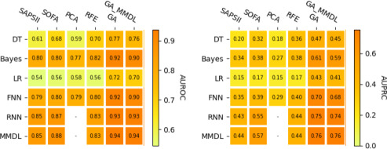

Fig. 1. Apply the features selected by GA-MMDL to other classifiers for the mortality prediction task.

### 4.2. ICD-9 code prediction task evaluation

We divided the dataset into 20 classes according to [6] and treated it as a multi-classification task. However, because Bayes and LR in the package of scikit-learn do not support multi-classification tasks, we perform [binary classification](https://www.sciencedirect.com/topics/computer-science/binary-classification) for these two algorithms and then calculate the average AUROC and AUPRC as the final results.

Table 6. AUROC of icd-9 code group prediction task.

| Algorithm Empty Cell | Algorithm Empty Cell | Score method (Features) SAPS-II (20) | Score method (Features) SOFA (17) | Feature extraction/selection (Features) PCA (20) | Feature extraction/selection (Features) RFE (20) | Feature extraction/selection (Features) GA (20) | All features (141) Empty Cell |
| --- | --- | --- | --- | --- | --- | --- | --- |
| ML | DT | 0.5735 ± 0.0004 | 0.5746 ± 0.0003 | 0.5609 ± 0.0005 | 0.5633 ± 0.0011 | **0.5875 ± 0.0005** | 0.5868 ± 0.0011 |
|  | Bayes | 0.6818 ± 0.0010 | 0.6694 ± 0.0023 | 0.6523 ± 0.0027 | 0.6993 ± 0.0052 | **0.7542 ± 0.0036** | 0.7505 ± 0.0023 |
|  | LR | 0.5454 ± 0.0004 | 0.5395 ± 0.0008 | 0.5438 ± 0.0006 | 0.5687 ± 0.0024 | **0.6064 ± 0.0023** | 0.6032 ± 0.0011 |
| DL | FNN | 0.8087 ± 0.0008 | 0.8034 ± 0.0014 | 0.8036 ± 0.0014 | 0.8158 ± 0.0002 | 0.8383 ± 0.0005 | **0.8408 ± 0.0007** |
|  | RNN | 0.8147 ± 0.0012 | 0.8121 ± 0.0001 | – | 0.8229 ± 0.0003 | 0.8351 ± 0.0005 | **0.8427 ± 0.0009** |
|  | MMDL | 0.8197 ± 0.0007 | 0.8179 ± 0.0003 | – | 0.8217 ± 0.0007 | 0.8384 ± 0.0007 | **0.8440 ± 0.0007** |

Table 7. AUPRC of icd-9 code group prediction task.

| Algorithm Empty Cell | Algorithm Empty Cell | Score method (Features) SAPS-II (20) | Score method (Features) SOFA (17) | Feature extraction/selection (Features) PCA (20) | Feature extraction/selection (Features) RFE (20) | Feature extraction/selection (Features) GA (20) | All features (141) Empty Cell |
| --- | --- | --- | --- | --- | --- | --- | --- |
| ML | DT | 0.3719 ± 0.0012 | 0.3740 ± 0.0018 | 0.3522 ± 0.0013 | 0.3538 ± 0.0014 | **0.3825 ± 0.0009** | 0.3820 ± 0.0008 |
|  | Bayes | 0.4523 ± 0.0006 | 0.4440 ± 0.0031 | 0.4096 ± 0.0031 | 0.4722 ± 0.0052 | **0.5206 ± 0.0051** | 0.5201 ± 0.0020 |
|  | LR | 0.3440 ± 0.0004 | 0.3400 ± 0.0005 | 0.3414 ± 0.0002 | 0.3739 ± 0.0035 | **0.4500 ± 0.0043** | 0.3896 ± 0.0018 |
| DL | FNN | 0.6698 ± 0.0033 | 0.6602 ± 0.0022 | 0.6552 ± 0.0047 | 0.6717 ± 0.0003 | 0.7148 ± 0.0009 | **0.7265 ± 0.0007** |
|  | RNN | 0.6820 ± 0.0006 | 0.6780 ± 0.0005 | – | 0.6897 ± 0.0008 | 0.7148 ± 0.0018 | **0.7311 ± 0.0022** |
|  | MMDL | 0.6911 ± 0.0021 | 0.6902 ± 0.0004 | – | 0.6925 ± 0.0029 | 0.7214 ± 0.0015 | **0.7340 ± 0.0005** |

Tables 6, 7 show the results of icd-9 code group prediction task. We can observe that: (a) [Deep learning](https://www.sciencedirect.com/topics/computer-science/deep-learning) prediction models perform better than traditional machine learning models and obtain around 9%–25% and 20%–35% improvement for AUROC and AUPRC, respectively. (b) GA performs better and obtains around 1%–10% improvement over other methods for both AUROC and AUPRC. (c) Compared with using all features (141 features), GA gets similar or even better results with only 20 features.

Fig. 2 shows the result of applying the features selected by GA-MMDL to other classifiers. We can observe that: (a) Only for deep learning models, the features that GA-MMDL chooses achieve similar results with the GA combined with the specific classifier. For machine learning classifiers, the features that GA-MMDL chooses do not perform well.

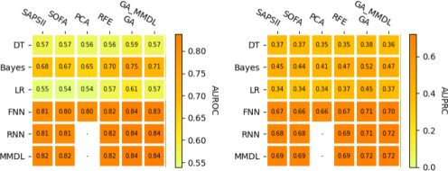

Fig. 2. Apply the features selected by GA-MMDL to other classifiers for icd-9 code prediction task.

### 4.3. Length of stay prediction task evaluation

Table 8 shows the results of the length of the stay prediction task. We remove the LR algorithm since it is not capable of processing [regression problems](https://www.sciencedirect.com/topics/computer-science/regression-problem). We can observe that: (a) GA performs better than others and obtains around 6%–30% improvement over other methods in terms of MSE (in hours). (b) Compared with using all features (141 features), GA gets similar or even better MSE with only 20 features, save time and money.

Table 8. MSE of length of stay prediction.

| Algorithm Empty Cell | Algorithm Empty Cell | Score method (Features) SAPS-II (20) | Score method (Features) SOFA (17) | Feature extraction/selection (Features) PCA (20) | Feature extraction/selection (Features) RFE (20) | Feature extraction/selection (Features) GA (20) | All features (141) Empty Cell |
| --- | --- | --- | --- | --- | --- | --- | --- |
| ML | DT | 54344.8815 ± 2390.9406 | 52836.9795 ± 3621.4408 | 54717.3409 ± 709.7653 | 48846.0888 ± 3862.0252 | **43468.6583 ± 2223.4084** | 45166.0388 ± 2853.9258 |
|  | Bayes | 58715.9520 ± 2012.4531 | 74876.8679 ± 22148.1398 | 58784.5393 ± 3291.4266 | 61219.8744 ± 3515.9883 | 53172.5127 ± 4091.2336 | **52564.0560 ± 2409.1296** |
| DL | FNN | 60096.6133 ± 4174.1588 | 61843.7995 ± 6065.2225 | 57233.4701 ± 6296.6451 | 60358.6628 ± 4690.3527 | **53843.4805 ± 3482.8460** | 60998.5990 ± 9321.8411 |
|  | RNN | 55031.8490 ± 3363.6808 | 54386.3086 ± 1304.0803 | – | 52148.4479 ± 1121.8866 | 43776.1263 ± 1633.5601 | **42790.0521 ± 1290.5697** |
|  | MMDL | 54876.1159 ± 2560.8740 | 54138.1146 ± 2704.3223 | – | 51897.9544 ± 1752.6679 | 44385.0039 ± 3158.0891 | **43398.7773 ± 4523.6935** |

Fig. 3 shows the result of applying the features selected by GA-MMDL to other regressors. We can observe that: (a) Only for the RNN model, the features GA-MMDL selects have good performance. For the other classifiers, the features that GA-MMDL chooses do not perform well.

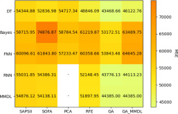

Fig. 3. Apply the features that GA-MMDL selects to other classifiers for the length of the stay prediction task.

### 4.4. Statistical significance tests of GA

From the above results, we can see that GA always performs better than other feature selection methods. We think this is because as the number of iterations (epochs) increases, GA can reach the local optimum. If there are enough iterations, GA can even reach the global optimum. The price of high precision is time overhead. However, this feature selection method only need to be trained once offline and in actual application doctors can quickly make a diagnosis with a few features.

Table 9. Whether is statistically significant with significance level 0.05.

| Task | Metric | SAPS-II | SOFA | PCA | RFE |
| --- | --- | --- | --- | --- | --- |
| Mortality | AUROC | Yes | No | Yes | Yes |
|  | AUPRC | Yes | Yes | Yes | Yes |
| ICD9 | AUROC | No | No | No | No |
|  | AUPRC | No | No | No | No |
| Length of stay | MSE | Yes | Yes | Yes | Yes |

## 5. Summary

As part of future work, we plan to make a severity-scoring system based on the features that GA-MMDL selects for the mortality task. This system promises doctors to quickly and accurately assess the severity of a patient’s disease with a few simple variables.

## References

1. [1]

   Johnson A.E., Pollard T.J., Shen L., Li-Wei H.L., Feng M., Ghassemi M., Moody B., Szolovits P., Celi L.A., Mark R.G.

   MIMIC-III, a freely accessible critical care database

   Sci. Data, 3 (1) (2016), pp. 1-9

   [CrossRef](https://doi.org/10.1002/9781119076506.wbeps202)Google Scholar
2. [2]

   Le Gall J.-R., Lemeshow S., Saulnier F.

   A new simplified acute physiology score (SAPS II) based on a European/North American multicenter study

   JAMA, 270 (24) (1993), pp. 2957-2963

   [CrossRef](https://doi.org/10.1001/jama.1993.03510240069035)Google Scholar
3. [3]

   Vincent J.-L., Moreno R., Takala J., Willatts S., De Mendonça A., Bruining H., Reinhart C., Suter P., Thijs L.G.

   The SOFA (Sepsis-related Organ Failure Assessment) score to describe organ dysfunction/failure

   Springer-Verlag (1996)

   Google Scholar
4. [4]

   Bhandoria G., Mane J.D.

   Can surgical apgar score (SAS) predict postoperative complications in patients undergoing gynecologic oncological surgery?

   Indian J. Surg. Oncol., 11 (1) (2020), pp. 60-65

   [CrossRef](https://doi.org/10.1007/s13193-019-00995-6)[View in Scopus](https://www.scopus.com/inward/record.url?eid=2-s2.0-85074887890&partnerID=10&rel=R3.0.0)Google Scholar
5. [5]

   Pirracchio R., Petersen M.L., Carone M., Rigon M.R., Chevret S., van der Laan M.J.

   Mortality prediction in intensive care units with the super ICU learner algorithm (SICULA): a population-based study

   Lancet Respir. Med., 3 (1) (2015), pp. 42-52

   [View PDF](https://www.sciencedirect.com/science/article/pii/S2213260014702395/pdfft?md5=6add567bd9e7f7a16fbfbead12f968f6&pid=1-s2.0-S2213260014702395-main.pdf)[View article](https://www.sciencedirect.com/science/article/pii/S2213260014702395)[View in Scopus](https://www.scopus.com/inward/record.url?eid=2-s2.0-84920273517&partnerID=10&rel=R3.0.0)Google Scholar
6. [6]

   Purushotham S., Meng C., Che Z., Liu Y.

   Benchmarking deep learning models on large healthcare datasets

   J. Biomed. Inform., 83 (2018), pp. 112-134

   [View PDF](https://www.sciencedirect.com/science/article/pii/S1532046418300716/pdfft?md5=2c2266a54e772aa8d5d157ec654e39cf&pid=1-s2.0-S1532046418300716-main.pdf)[View article](https://www.sciencedirect.com/science/article/pii/S1532046418300716)[View in Scopus](https://www.scopus.com/inward/record.url?eid=2-s2.0-85048265375&partnerID=10&rel=R3.0.0)Google Scholar
7. [7]

   Harutyunyan H., Khachatrian H., Kale D.C., Ver Steeg G., Galstyan A.

   Multitask learning and benchmarking with clinical time series data

   Sci. Data, 6 (1) (2019), pp. 1-18

   [View in Scopus](https://www.scopus.com/inward/record.url?eid=2-s2.0-85073145658&partnerID=10&rel=R3.0.0)Google Scholar
8. [8]

   Lee J.

   Patient-specific predictive modeling using random forests: an observational study for the critically ill

   JMIR Med. Inform., 5 (1) (2017), Article e3

   [CrossRef](https://doi.org/10.2196/medinform.6690)[View in Scopus](https://www.scopus.com/inward/record.url?eid=2-s2.0-85048308034&partnerID=10&rel=R3.0.0)Google Scholar
9. [9]

   Johnson A.E., Kramer A.A., Clifford G.D.

   A new severity of illness scale using a subset of acute physiology and chronic health evaluation data elements shows comparable predictive accuracy

   Crit. Care Med., 41 (7) (2013), pp. 1711-1718

   [View in Scopus](https://www.scopus.com/inward/record.url?eid=2-s2.0-84880558601&partnerID=10&rel=R3.0.0)Google Scholar
10. [10]

    Krishnan G.S., Kamath S.

    A novel GA-ELM model for patient-specific mortality prediction over large-scale lab event data

    Appl. Soft Comput., 80 (2019), pp. 525-533

    Google Scholar
11. [11]

    Knaus W.A., Draper E.A., Wagner D.P., Zimmerman J.E.

    APACHE II: a severity of disease classification system

    Crit. Care Med., 13 (10) (1985), pp. 818-829

    [CrossRef](https://doi.org/10.1097/00003246-198510000-00009)[View in Scopus](https://www.scopus.com/inward/record.url?eid=2-s2.0-0022256529&partnerID=10&rel=R3.0.0)Google Scholar
12. [12]

    Le Gall J.-R., Loirat P., Alperovitch A., Glaser P., Granthil C., Mathieu D., Mercier P., Thomas R., Villers D.

    A simplified acute physiology score for ICU patients

    Crit. Care Med., 12 (11) (1984), pp. 975-977

    [View in Scopus](https://www.scopus.com/inward/record.url?eid=2-s2.0-0021739699&partnerID=10&rel=R3.0.0)Google Scholar
13. [13]

    Hoogendoorn M., El Hassouni A., Mok K., Ghassemi M., Szolovits P.

    Prediction using patient comparison vs. modeling: a case study for mortality prediction

    2016 38th Annual International Conference of the IEEE Engineering in Medicine and Biology Society, EMBC, IEEE (2016), pp. 2464-2467

    [View in Scopus](https://www.scopus.com/inward/record.url?eid=2-s2.0-85009128708&partnerID=10&rel=R3.0.0)Google Scholar
14. [14]

    Calvert J., Mao Q., Hoffman J.L., Jay M., Desautels T., Mohamadlou H., Chettipally U., Das R.

    Using electronic health record collected clinical variables to predict medical intensive care unit mortality

    Ann. Med. Surg., 11 (2016), pp. 52-57

    [View PDF](https://www.sciencedirect.com/science/article/pii/S2049080116301315/pdfft?md5=e414cdb8f0869a610c8dd6e1b3ba51cf&pid=1-s2.0-S2049080116301315-main.pdf)[View article](https://www.sciencedirect.com/science/article/pii/S2049080116301315)[CrossRef](https://doi.org/10.1016/j.amsu.2016.09.002)[View in Scopus](https://www.scopus.com/inward/record.url?eid=2-s2.0-84988564562&partnerID=10&rel=R3.0.0)Google Scholar
15. [15]

    Pirracchio R.

    Mortality prediction in the icu based on mimic-ii results from the super icu learner algorithm (sicula) project

    Secondary Analysis of Electronic Health Records, Springer (2016), pp. 295-313

    [CrossRef](https://doi.org/10.1007/978-3-319-43742-2_20)[View in Scopus](https://www.scopus.com/inward/record.url?eid=2-s2.0-85024394244&partnerID=10&rel=R3.0.0)Google Scholar
16. [16]

    Ahmad R., Bath P.A.

    Identification of risk factors for 15-year mortality among community-dwelling older people using cox regression and a genetic algorithm

    J. Gerontol. (A Biol. Sci. Med. Sci.), 60 (8) (2005), pp. 1052-1058

    [CrossRef](https://doi.org/10.1093/gerona/60.8.1052)[View in Scopus](https://www.scopus.com/inward/record.url?eid=2-s2.0-24144469746&partnerID=10&rel=R3.0.0)Google Scholar
17. [17]

    Adams L.J., Bello G., Dumancas G.G.

    Development and application of a genetic algorithm for variable optimization and predictive modeling of five-year mortality using questionnaire data

    Bioinform. Biol. Insights, 9 (2015), pp. BBI-S29469

    Google Scholar
18. [18]

    Chan C.-L., Ting H.-W.

    Constructing a novel mortality prediction model with Bayes theorem and genetic algorithm

    Expert Syst. Appl., 38 (7) (2011), pp. 7924-7928

    [View PDF](https://www.sciencedirect.com/science/article/pii/S0957417410013503/pdfft?md5=468bbd16b78f454728b20608daf1285d&pid=1-s2.0-S0957417410013503-main.pdf)[View article](https://www.sciencedirect.com/science/article/pii/S0957417410013503)[View in Scopus](https://www.scopus.com/inward/record.url?eid=2-s2.0-79952448532&partnerID=10&rel=R3.0.0)Google Scholar
19. [19]

    Engoren M.C., Moreno R., Miranda D.R.

    A genetic algorithm to predict hospital mortality in an ICU population

    Crit. Care Med., 27 (12) (1999), p. A52

    [View in Scopus](https://www.scopus.com/inward/record.url?eid=2-s2.0-26444554156&partnerID=10&rel=R3.0.0)Google Scholar
20. [20]

    A.E. Johnson, T.J. Pollard, R.G. Mark, Reproducibility in critical care: a mortality prediction case study, in: Machine Learning for Healthcare Conference, 2017, pp. 361–376.

    Google Scholar
21. [21]

    Mitchell M.

    An Introduction to Genetic Algorithms, Vol. 1996

    MIT press, Cambridge, Massachusetts. London, England (1996)

    [Google Scholar](https://scholar.google.com/scholar_lookup?title=An%20Introduction%20to%20Genetic%20Algorithms%2C%20Vol.%201996&publication_year=1996&author=M.%20Mitchell)
22. [22]

    Pearson K.

    LIII. on lines and planes of closest fit to systems of points in space

    Lond. Edinb. Dublin Philos. Mag. J. Sci., 2 (11) (1901), pp. 559-572

    [CrossRef](https://doi.org/10.1080/14786440109462720)[Google Scholar](https://scholar.google.com/scholar_lookup?title=LIII.%20on%20lines%20and%20planes%20of%20closest%20fit%20to%20systems%20of%20points%20in%20space&publication_year=1901&author=K.%20Pearson)

## Cited by (0)

© 2021 The Authors. Publishing services by Elsevier B.V. on behalf of KeAi Communications Co. Ltd.

  Jiaqiang Liu, …, Guangzhong Sun

  [View PDF](https://www.sciencedirect.com/science/article/pii/S2772485921000090/pdfft?md5=e3e618453811eda67a8549ff2a96e500&pid=1-s2.0-S2772485921000090-main.pdf)

- BenchCouncil Transactions on Benchmarks, Standards and Evaluations, Volume 1, Issue 1, 2021, Article 100008

  Lin Li, …, Tian-Zhu Xiang

  [View PDF](https://www.sciencedirect.com/science/article/pii/S2772485921000089/pdfft?md5=d1824b70c714277bd224e6db44b1b71a&pid=1-s2.0-S2772485921000089-main.pdf)

- BenchCouncil Transactions on Benchmarks, Standards and Evaluations, Volume 1, Issue 1, 2021, Article 100003

  Varun Gohil, …, Manu Awasthi

  [View PDF](https://www.sciencedirect.com/science/article/pii/S277248592100003X/pdfft?md5=3477132301a132ff0fdf5f9370443f35&pid=1-s2.0-S277248592100003X-main.pdf)

[View details](https://plu.mx/plum/a/?doi=10.1016/j.tbench.2021.100004&theme=plum-sciencedirect-theme&hideUsage=true)

View PDF